# Researching Digital Life

Lecture 7: Screen-scraping and APIs

Christopher Barrie

University of Edinburgh | [RDL](https://github.com/cjbarrie/RDL-Ed)

# Week 7: Screen-scraping and APIs

This week you had readings by Freelon (2018), Bruns (2019), Puschmann (2019), and Lazer et al. (2020) as well as a [report](https://www.disinfobservatory.org/download/26541) by SOMA outlining solutions for research data exchange.

The hands-on exercise for this week uses different sources of online data, and here I introduce you to how we might gather data through both screen-scraping (or server-side) techniques as well as API (or client-side) techniques.

## Setup

To practice these skills, we will use a series of webpages on the Internet Archive that host material collected at the Arab Spring protests in Egypt in 2011. The original website can be seen [here](https://www.tahrirdocuments.org/) and below.

[interactive chart not shown]

## Load data and packages

Beforce proceeding, we’ll load the remaining packages we will need for this tutorial.

```r
library(tidyverse) # loads dplyr, ggplot2, and others
library(ggthemes) # includes a set of themes to make your visualizations look nice!
library(readr) # more informative and easy way to import data
library(stringr) # to handle text elements
library(rvest) #for scraping
```

We can download the final dataset we will produce with:

```r
pamphdata <- read_csv("data/pamphlets_formatted_gsheets.csv")
```

If you’re working on this document from your own computer (“locally”) you can download the Tahrir documents data in the following way:

```r
pamphdata <- read_csv("https://raw.githubusercontent.com/cjbarrie/RDL-Ed/main/03-screenscrape-apis/data/pamphlets_formatted_gsheets.csv")
```

## Inspect and filter data

Let’s have a look at what we will end up producing:

```r
colnames(pamphdata)
```

```
## [1] "title"    "date"     "year"     "text"     "tags"     "imageurl" "imgID"
## [8] "image"
```

And then:

```r
glimpse(pamphdata)
```

```
## Rows: 523
## Columns: 8
## $ title    <chr> "The Season of Anger Sets in Among the Arab Peoples", "The M…
## $ date     <date> 2011-03-30, 2011-03-30, 2011-03-30, 2011-03-30, 2011-03-30,…
## $ year     <dbl> 2011, 2011, 2011, 2011, 2011, 2011, 2011, 2011, 2011, 2011, …
## $ text     <chr> "The Season of Anger Sets in Among the Arab Peoples,,A membe…
## $ tags     <chr> "Solidarity", "Solidarity, Workers", "Solidarity, Workers", …
## $ imageurl <chr> "https://wayback.archive-it.org/2358/20120130161341im_/http:…
## $ imgID    <chr> "imgID1", "imgID2", "imgID3", "imgID4", "imgID5", "imgID6", …
## $ image    <chr> "=Arrayformula(image(F2,2))", NA, NA, NA, NA, NA, NA, NA, NA…
```

## Inspecting HTML contents

We are going to return to the Internet Archived webpages to see how we can produce this final formatted dataset. The archived Tahrir Documents webpages can be accessed [here](https://wayback.archive-it.org/2358/20120130143023/http://www.tahrirdocuments.org/).

We first want to expect how the contents of each webage is stored.

When we scroll to the very bottom of the page, we see listed a number of hyperlinks to documents stored by month:

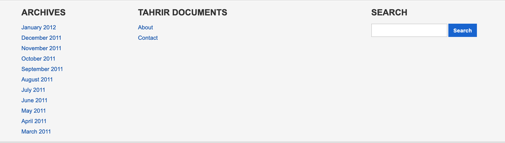

We will click through the documents stored for March and then click on the top listed pamphlet entitled “The Season of Anger Sets in Among the Arab Peoples.” You can access this [here](https://wayback.archive-it.org/2358/20120130161341/http://www.tahrirdocuments.org/2011/03/voice-of-the-revolution-3-page-2/).

We will store this url to inspect the HTML it contains as follows:

```r
url <- "https://wayback.archive-it.org/2358/20120130161341/http://www.tahrirdocuments.org/2011/03/voice-of-the-revolution-3-page-2/"

html <- read_html(url)
```

```r
pagetext <- html %>%
  html_text()

pagetext
```

```
## [1] "\n\tWB_wombat_Init(\"https://wayback.archive-it.org/2358/\", \"20120130161341\", \"www.tahrirdocuments.org\");\n  The Season of Anger Sets in Among the Arab Peoples//<![CDATA[\n\t// Google Analytics for WordPress by Yoast v4.0.10 | http://yoast.com/wordpress/google-analytics/\n\tvar _gaq = _…
```

Well this looks pretty terrifying too…

```r
pagetext <- html %>%
  html_nodes("p") %>%
  html_text(trim=TRUE)

pagetext
```

```
##  [1] ""
##  [2] ""
##  [3] "Click here to download the original."
##  [4] "The Season of Anger Sets in Among the Arab Peoples"
##  [5] ""
##  [6] "A member of the Algerian opposition warned the Arab rulers that the Tunisian revolution would initiate a revolutionary tsunami phenomenon that would sweep away their thrones. At the beginning of last December, the end of the dictatorial regimes began with successive protests against high pr…
##  [7] ""
##  [8] "The issue is not one of infection; rather, the subjugated peoples discovered the potential of their own free will. The revolution in one country inspired the populations in other countries, for people imprison themselves in waiting, hoping and yearning, until their spirits emerge carrying t…
##  [9] ""
## [10] "Beyond inspiration and transmitting experience, there is also solidarity, for the Tunisian revolution’s victory celebrations spread to Jordan and Egypt. And most of the Arab peoples participated in Egypt’s joy. There were many moving scenes, like the singing of the national anthem and the d…
## [11] ""
## [12] "However, the regimes that consolidate their interests over and against the people’s also rely on one another and exchange their experiences with oppression and harassment. And now confrontations are raging in Bahrain, Yemen, and Libya as mummified regimes committing increased acts of violen…
## [13] ""
## [14] "The solidarity and support of the Arab revolutions for each other is the destiny of the Arab region and the only way to protect the interests and wealth of its peoples.  With the extinct regime issuing threats—as if from another world—that Omar Suleiman, Mubarak, or Ria and Sikina will retu…
## [15] ""
## [16] "________________________"
## [17] "Acquired March 2011"
## [18] "Translated by Yasmeen Mekawy"
## [19] "Translation reviewed by Emily Drumsta"
## [20] ""
## [21] ""
## [22] "« The Most Important Workers’ Protests The Popular Alliance Party: Foundational Declaration »"
## [23] "Tahrir Documents is an ongoing effort to archive and translate activist papers from the 2011 Egyptian uprising and its aftermath. Materials are collected from demonstrations in Cairo’s Tahrir Square and published in complete English translation alongside scans of the original documents. The…
## [24] "For more information please contact tahrirdocuments@gmail.com"
## [25] "Designed by"
## [26] "Copyright © 2012 Tahrir Documents. All rights reserved."
```

, which looks quite a lot more manageable…!

## Inspecting URL structures

We first need to inspect the URL structures of the documents we want to capture. When we scroll down the page we see listed a number of documents. Each of these directs to an individual pamphlet distributed at protests during the 2011 Egyptian Revolution.

Click on one of these and see how the URL changes.

We see that if our starting URL was:

```
https://wayback.archive-it.org/2358/20120130135111/http://www.tahrirdocuments.org/
```

Then if we click on March 2011, the first month for which we have documents, we see that the url becomes:

```
https://wayback.archive-it.org/2358/20120130143023/http://www.tahrirdocuments.org/2011/03/
```

, for August 2011 it becomes:

```
https://wayback.archive-it.org/2358/20120130142155/http://www.tahrirdocuments.org/2011/08/
```

, and for January 2012 it becomes:

```
https://wayback.archive-it.org/2358/20120130142014/http://www.tahrirdocuments.org/2012/01/
```

We notice that for each month, the URL changes with the addition of month and year between back slashes at the end or the URL. In the next section, we will go through how to efficiently create a set of URLs to loop through and retrieve the information contained in each individual webpage.

## Looping through URLs

We are going to want to retrieve the text of documents archived for each month. As such, our first task is to store each of these webpages as a series of strings. We could do this manually by, for example, pasting year and month strings to the end of each URL for each month from March, 2011 to January, 2012:

```r
url <- "https://wayback.archive-it.org/2358/20120130143023/http://www.tahrirdocuments.org/"

url1 <- paste0(url,"2011/03/")
url2 <- paste0(url,"2011/04/")
url3 <- paste0(url,"2011/04/")

#etc...

urls <- c(url1, url2, url3)
```

But this wouldn’t be particularly efficient…

Instead, we can wrap all of this in a loop.

```r
urls <- character(0)
for (i in 3:13) {
  url <- "https://wayback.archive-it.org/2358/20120130143023/http://www.tahrirdocuments.org/"
  newurl <- ifelse(i <10, paste0(url,"2011/0",i,"/"),
                   ifelse(i>=10 & i<=12 , paste0(url,"2011/",i,"/"),
                          paste0(url,"2012/01/")))
  urls <- c(urls, newurl)
}
```

What’s going on here? Well, we are first specifying the starting URL as above. We are then iterating through the numbers 3 to 13. And we are telling R to take the new URL and then, depending on the number in the loop we are on, to take the base starting url— https://wayback.archive-it.org/2358/20120130143023/http://www.tahrirdocuments.org/ — and to paste on the end of it the string “2011/0”, then the number of the loop we are on, and then “/”. So, for the first “i” in the loop—the number 3—then we are effectively calling the equivalent of:

```r
i
```

[output not shown]

```r
url <- "https://wayback.archive-it.org/2358/20120130143023/http://www.tahrirdocuments.org/"
newurl <- paste0(url,"2011/0",3,"/")
```

Which gives:

```
## [1] "https://wayback.archive-it.org/2358/20120130143023/http://www.tahrirdocuments.org/2011/03/"
```

In the above, the `ifelse()` commands are simply telling R: if i (the number of the loop we are on) is less than 10 then `paste0(url,"2011/0",i,"/")`; i.e., if i is less than 10 then paste “2011/0”, then “i” and then “/”. So for the number 3 this becomes:

`"https://wayback.archive-it.org/2358/20120130143023/http://www.tahrirdocuments.org/2011/03/"`

, and for the number 4 this becomes

`"https://wayback.archive-it.org/2358/20120130143023/http://www.tahrirdocuments.org/2011/04/"`

If, however, `i>=10 & i<=12` (i is greater than or equal to 10 and less than or equal to 12) then we are calling `paste0(url,"2011/",i,"/")` because here we do not need the first “0” after in the months. Finally, if (else) i is greater than 12 then we are calling `paste0(url,"2012/01/")`. For this last call, notice, we do not have to specify whether i is greater than or equal to 12 because we are wrapping everything in `ifelse()` commands. With `ifelse()` calls like this, we are telling R if x “meets condition” then do y, ortherwise do z. When we are wrapping multiple `ifelse()` calls within each other, we are effectively telling R if x “meets condition” then do y, or if x “meets other condition” then do z, otherwise do a. So here, the “otherwise do a” part of the `ifelse()` calls is saying: if i is not less than 10, and is not between 10 and 12, then paste “2012/01/” to the end of the URL.

## References

Bruns, Axel. 2019. “After the ‘APIcalypse’: Social Media Platforms and Their Fight Against Critical Scholarly Research.” *Information, Communication & Society* 22 (11): 1544–66. https://doi.org/10.1080/1369118X.2019.1637447.

Freelon, Deen. 2018. “Computational Research in the Post-API Age.” *Political Communication* 35 (4): 665–68. https://doi.org/10.1080/10584609.2018.1477506.

Lazer, David M. J., Alex Pentland, Duncan J. Watts, Sinan Aral, Susan Athey, Noshir Contractor, Deen Freelon, et al. 2020. “Computational Social Science: Obstacles and Opportunities.” *Science* 369 (6507): 1060–2. https://doi.org/10.1126/science.aaz8170.

Puschmann, Cornelius. 2019. “An End to the Wild West of Social Media Research: A Response to Axel Bruns.” *Information, Communication & Society* 22 (11): 1582–9. https://doi.org/10.1080/1369118X.2019.1646300.